# Analysis and Modeling

Kaila Gilbert, Matt Samach

December 4, 2019

## Model Goodies

```r
library(ggplot2)
library(dplyr)
library(lubridate)
library(hms)
library(tidyr)
set.seed(1)
file_path = "/Users/matty_sam/Dropbox/Documents/CMU/Classes/Fall 2019/Applied ML/Project/Data/Imputed/data1.csv"
main_df = read.csv(file_path)
```

First, we transformed our data set to exclude a few columns that would not be pertinent to the end user (inspection agency.) We also transformed expense columsn, ordinal factor data, into continuous integers.

```r
main_df <- main_df %>%
  mutate_at(vars(matches("prev")), as.factor) %>%
  select(-state, -morning)

#Dropping the Ordinal BS
money_df <- main_df %>%
  mutate_at(
    vars(matches("Expense"), matches("Sales")),
    funs(case_when(
  .=="Less than $500" ~ 250,
  .=="$500 to $1,000" ~ 750,
  .== "Less than $1,000" ~ 500,
  .=="$1,000 to $2,500" ~ 1750,
  .=="$1,000 to $5,000"~3000,
  .=="Less than $2,000"~1000,
  .=="$2,000 to $5,000"~ 3500,
  .=="Less than $2,500" ~1250,
  .=="$2,500 to $5,000" ~ 3750,
  .=="Less than $5,000"~2500,
  .=="$5,000 to $10,000" ~ 7500,
  .=="$1,000 to $10,000" ~ 5000,
  .=="Less than $10,000"~5000,
  .=="$5,000 to $20,000"~12500,
  .=="$10,000 to $20,000" ~ 15000,
  .=="$10,000 to $25,000" ~17500,
  .=="$20,000 to $50,000" ~35000,
  .=="$25,000 to $50,000" ~37500,
  .=="Over $25,000" ~ 25000,
  .=="$10,000 to $50,000" ~25000,
  .=="Over $50,000" ~ 50000,
  .=="Less than $100,000"~50000,
  .=="$50,000 to $100,000" ~ 75000,
  .=="Over $100,000" ~ 100000,
  .=="$100,000 to $250,000" ~ 175000,
  .=="Over $250,000"~250000,
  .=="$250,000 to $500,000" ~375000,
  .=="Less Than $500,000" ~250000,
  .=="Over $500,000" ~ 500000,
  .=="$500,000 to $1 Million"~750000,
  .=="$1 to $2.5 Million"~ 1750000,
  .=="$2.5 Million to $10 Million" ~6250000,
  .=="Over $10 Million" ~10000000,
  .=="$1-2.5 Million" ~1750000,
  .=="$2.5-5 Million"~3750000,
  .=="$20-50 Million"~35000000,
  .=="$5-10 Million"~7500000,
  .=="$10-20 Million" ~15000000,
  .=="$50-100 Million" ~75000000,
  .=="$100-500 Million" ~300000000,
  .=="$500,000-1 Million"~750000

)))
```

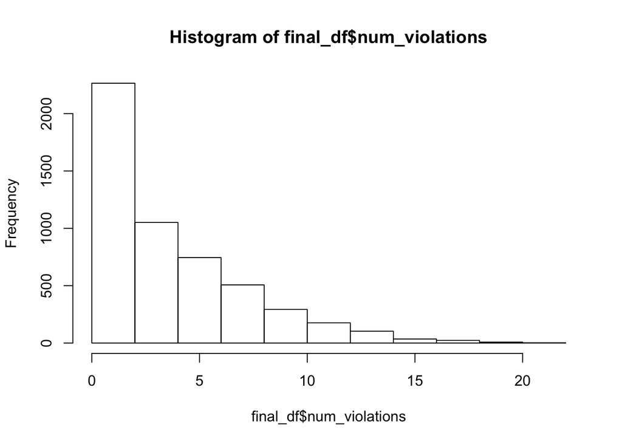

```r
other_ords <- money_df %>%
  mutate_at(
    vars(matches("Square")),
    funs(case_when(
    .== "1 - 1,499" ~1249,
    .=="1,500 - 2,499"   ~1999,
    .=="2,500 - 4,999" ~3749,
    .=="5,000 - 9,999" ~7499,
    .=="10,000 - 19,999" ~14999,
    .=="20,000 - 39,999" ~29999,
    .=="40,000 - 99,999" ~69999,
    .=="100,000+"   ~100000

    )))

emp_ords <- other_ords %>%
  mutate_at(
    vars(matches("Size.Range")),
    funs(case_when(
  .=="1 to 4"   ~2.5,
  .=="5 to 9" ~7,
  .=="10 to 19"  ~14.5,
  .=="20 to 49" ~34.5,
   .=="50 to 99"  ~74.5,
  .=="100 to 249" ~174.5,
  .=="250 to 499" ~374.5,
  .=="500 to 999" ~749.5
)))

#Make Date Continuous
final_df <- emp_ords %>%
 mutate(bus_st_date=as.numeric(as.Date(emp_ords$bus_st_date) - as.Date("1900-01-01")))%>%
  select(-c("status","Primary.SIC.Year.Appeared", "duration"))
#Remove duration, since beyond regulator's decision-making

#Lots of Small Businesses
hist(final_df$num_violations)
```

```r
#double-check
str(final_df)
```

```
## 'data.frame':    5208 obs. of  61 variables:
##  $ bus_st_date                                                  : num  31210 31210 31210 31210 30849 ...
##  $ description                                                  : Factor w/ 33 levels "Adult Food Service",..: 25 25 25 25 16 16 16 16 16 16 ...
##  $ city                                                         : Factor w/ 47 levels "Allison Park",..: 35 35 35 35 43 43 43 43 43 43 ...
##  $ purpose                                                      : Factor w/ 17 levels "Administrative Action",..: 6 6 6 6 6 6 6 7 11 6 ...
##  $ Executive.Title                                              : Factor w/ 17 levels "Administrator",..: 11 11 11 11 3 3 3 3 3 3 ...
##  $ Executive.Gender                                             : Factor w/ 2 levels "Female","Male": 1 1 1 1 1 1 1 1 1 1 ...
##  $ Location.Employee.Size.Range                                 : num  14.5 14.5 14.5 14.5 749.5 ...
##  $ Location.Sales.Volume.Range                                  : num  7.5e+05 7.5e+05 7.5e+05 7.5e+05 7.5e+05 7.5e+06 1.5e+07 7.5e+06 7.5e+06 7.5e+06 ...
##  $ Type.of.Business                                             : Factor w/ 2 levels "Branch of Public Company",..: 2 2 2 2 2 2 2 2 2 2 ...
##  $ Location.Type                                                : Factor w/ 4 levels "Branch","Headquarter",..: 3 3 3 3 4 4 4 4 4 4 ...
##  $ Square.Footage                                               : num  3749 3749 3749 3749 100000 ...
##  $ Home.Business                                                : Factor w/ 2 levels "No","Yes": 1 1 1 1 1 1 1 1 1 1 ...
##  $ Accounting.Expenses                                          : num  1750 1750 1750 1750 25000 25000 25000 25000 25000 25000 ...
##  $ Advertising..Expenses                                        : num  15000 15000 15000 15000 250000 250000 250000 250000 250000 250000 ...
```

[output cut: 47 more lines]

```r
purposes = final_df %>%
  group_by(purpose) %>%
  summarize(count = n()) %>%
  ungroup() %>%
  rename(number = count) %>%
  arrange(desc(number))

bus_categories = final_df %>%
  group_by(description) %>%
  summarize(count = n()) %>%
  ungroup() %>%
  rename(category = description,
         number = count) %>%
  arrange(desc(number))

city_count = final_df %>%
  group_by(city) %>%
  summarize(count = n()) %>%
  ungroup() %>%
  rename(number = count) %>%
  arrange(desc(number))

exec_titles = final_df %>%
    group_by(Executive.Title) %>%
  summarize(count = n()) %>%
  ungroup() %>%
  rename(number = count) %>%
  arrange(desc(number))

bus_start_dates = final_df %>%
    group_by(bus_st_date) %>%
  summarize(count = n()) %>%
  ungroup() %>%
  rename(number = count) %>%
  arrange(desc(number))

locations = final_df %>%
    group_by(Location.Type) %>%
  summarize(count = n()) %>%
  ungroup() %>%
  rename(number = count) %>%
  arrange(desc(number))


#Removing values with less than 5 occurences
scarce_purposes = purposes %>%
  subset(number<5)
scarce_categories = bus_categories %>%
  subset(number<5)
scarce_cities = city_count %>%
  subset(number<5)
scarce_exec = exec_titles %>%
  subset(number <5)
scarce_locations = locations %>%
  subset(number<5)

final_df <- final_df %>%
  subset(!(purpose %in% scarce_purposes[[1]] | description %in% scarce_categories[[1]] | city %in% scarce_cities[[1]] | Executive.Title %in% scarce_exec[[1]]|Location.Type %in% scarce_locations[[1]])) %>%
  select(-prev..Employee.Health)
```

A positive event occurs only 0.7% of the time. Doh!

We begin by running a simple linear regression on the number of violations.

```r
# Model
linear_reg <- lm(num_violations~., data=co_train_set %>% select(-log_violations))

# Get predictions from linear regression
lin_pred <- predict(linear_reg, co_test_set %>% select(-c(num_violations, log_violations)))

# Model accuracy measure is MSE. Get linear MSE.
lin_mse <- mean((lin_pred - co_test_set$num_violations)^2)

lin_mse
```

```
## [1] 10.56236
```

We now use a random forest model on number of violations.

```r
library(randomForest)
```

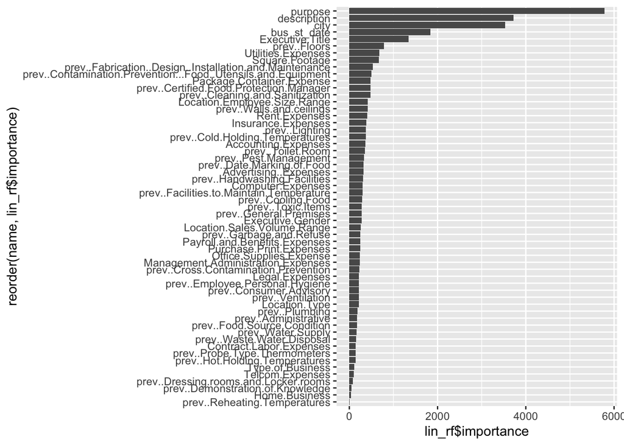

```r
# Model
lin_rf = randomForest(formula = num_violations ~ ., data=co_train_set %>% select(-log_violations), ntrees=15)

# Variable Importance Plot
ggplot(data=lin_rf$importance %>% as.data.frame() %>%
         mutate(name=as.factor(rownames(.))) %>%
         mutate(name=factor(name, name))) +
  geom_bar(aes(x=reorder(name, lin_rf$importance), y=lin_rf$importance), stat="identity") + coord_flip()
```

```r
# RF predictions
lin_rf_pred <- predict(lin_rf, co_test_set %>% select(-c(log_violations, num_violations)), n.trees=15)

# Get MSE for RF model
rf_lin_mse <- mean((lin_rf_pred - co_test_set$num_violations)^2)

rf_lin_mse
```

```
## [1] 9.575582
```

We will now run similar models but using log(number of violations) as our outcome variable.

```r
# Model
linear_log_reg <- lm(log_violations~., data=co_train_set %>% select(-num_violations))

# Get predictions from linear regression
lin_log_pred <- predict(linear_log_reg, co_test_set %>% select(-c(log_violations, num_violations)))

# Model accuracy measure is MSE. Get linear MSE.
lin_log_mse <- mean((lin_log_pred - co_test_set$log_violations)^2)

lin_log_mse
```

```
## [1] 0.4653054
```

We now fit a random forest model to log(number of violations)

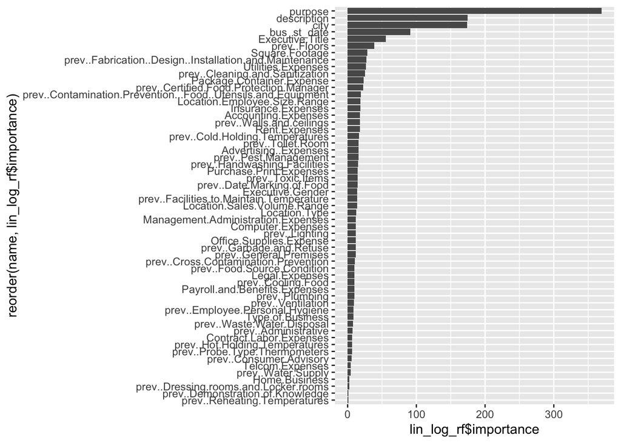

```r
# Model
lin_log_rf = randomForest(formula = log_violations ~ ., data=co_train_set %>% select(-num_violations), ntrees=15)

# Variable Importance Plot
ggplot(data=lin_log_rf$importance %>% as.data.frame() %>%
         mutate(name=as.factor(rownames(.))) %>%
         mutate(name=factor(name, name))) +
  geom_bar(aes(x=reorder(name, lin_log_rf$importance), y=lin_log_rf$importance), stat="identity") + coord_flip()
```

```r
# RF predictions
lin_log_rf_pred <- predict(lin_log_rf, co_test_set %>% select(-c(log_violations, num_violations)), n.trees=15)

# Get MSE for RF model
rf_lin_log_mse <- mean((lin_log_rf_pred - co_test_set$log_violations)^2)

rf_lin_log_mse
```

```
## [1] 0.4271111
```

We see similar outcomes with the random forest marginally outperforming a simple linear regression.

We will now focus on our binary outcome variable. We define this outcome as whether or not the inspection ended up with a “Inspected & Permitted” designation, or any other designation which would imply some sort of abnormality.

First we build the binary outcome datasets.

```r
#Creating Binary Indicator for Abnormal Inspection Outcome
binary_df <- final_df %>%
  mutate(outcome=as.factor(ifelse(placard_desc== "Inspected & Permitted", 0, 1))) %>%
  select(-c(log_violations, placard_desc, num_violations))

#Examination of Outcome Variable
prop.table(table(binary_df$outcome))
```

```
##
##           0           1
## 0.993252362 0.006747638
```

```r
table(binary_df$outcome)
```

```
##
##    0    1
## 5152   35
```

```r
#Binary Classification Requires Some More Work
bi_train_set <- binary_df[1:H,]
bi_test_set <- binary_df[(H+1):N,]

btrain_lab <- bi_train_set %>% select(outcome)
btrain_feat <- bi_train_set %>% select(-outcome)
btest_lab <- bi_test_set %>% select(outcome)
btest_feat <- bi_test_set %>% select(-outcome)
```

We see an extreme imbalance in our data outcomes. Out of all 5187 rows of data, only 35 (0.67%) outcomes were abnormal.

We will attempt to model on this extremely unbalanced set and later use SMOTE methodology to simulate outcome balance. We will use ROC curves and AUC to evaluate our models.

First we use a logistic regression model.

```r
library(ROCR)
# Model and predictions
logit_reg <- glm(formula=outcome ~., data = bi_train_set, family = binomial("logit"))
logit_pred <- predict(logit_reg, btest_feat, type="response") %>% as.data.frame()

# ROCR object
logit_rocr = prediction(logit_pred, bi_test_set$outcome)

# Get AUC
logit_auc = performance(logit_rocr, measure = "auc")
logit_auc@y.values
```

```
## [[1]]
## [1] 0.496892
```

```r
# Get ROC
logit_roc = performance(logit_rocr, measure = "tpr", x.measure = "fpr")
```

Next we use a random forrest classification model.

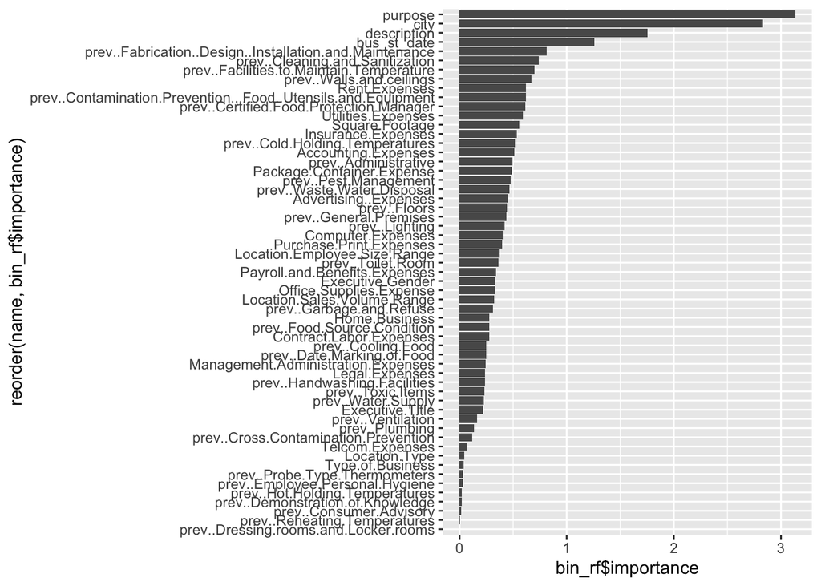

```r
# Model
bin_rf = randomForest(formula = outcome ~ ., data=bi_train_set, ntrees=15)

# Variable Importance Plot
ggplot(data=bin_rf$importance %>% as.data.frame() %>%
         mutate(name=as.factor(rownames(.))) %>%
         mutate(name=factor(name, name))) +
  geom_bar(aes(x=reorder(name, bin_rf$importance), y=bin_rf$importance), stat="identity") + coord_flip()
```

```r
# RF predictions
bin_rf_pred <- predict(bin_rf, bi_test_set %>% select(-outcome), n.trees=15, type = "prob")[, 2]

# ROCR object
bin_rf_rocr = prediction(bin_rf_pred, bi_test_set$outcome)

# Get AUC
bin_rf_auc = performance(bin_rf_rocr, measure = "auc")
bin_rf_auc@y.values
```

```
## [[1]]
## [1] 0.5735084
```

```r
# Get ROC
bin_rf_roc = performance(bin_rf_rocr, measure = "tpr", x.measure = "fpr")
```

We will graph the two ROC curves in order to compare the outcomes of the models.

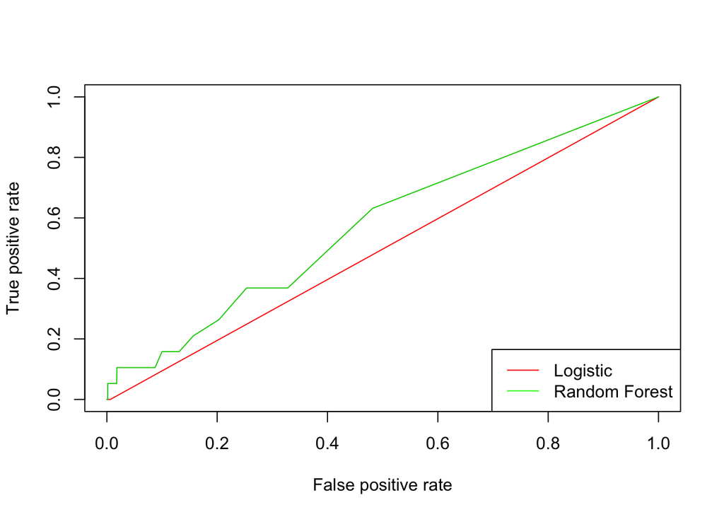

```r
plot(logit_roc , col = 2)
plot(bin_rf_roc, col = 3, add = TRUE)
legend("bottomright", c("Logistic", "Random Forest"), lty=1, col = c("red", "green"))
```

The logistic regression model has an AUC under 0.5, making it WORSE than random chance. The random forest does somewhat better with an AUC of 0.5735084.

Because our outcome data is so heavily imbalanced, we want to use over/under sampling methods to train models that could make more interesting models.

First we build our resampled dataset.

```r
library(DMwR)
# Do an 80/20 split on the original binary dataframe for train & test. Will only SMOTE train.

binary_df = binary_df[sample(1:nrow(binary_df)), ] #shuffle
H_bin = round(nrow(binary_df) * 0.8)
binary_train = binary_df[1:H_bin, ]
binary_test = binary_df[(H_bin + 1):nrow(binary_df), ]

#Oversampling minority data by 20% and undersampling majority by 20%
smoted_df = SMOTE(outcome~., binary_train, perc.over=100, k=5, perc.under=200)

#Did it work?
nrow(subset(smoted_df, outcome==1))/nrow(smoted_df)  #Balanced Dataset;
```

```
## [1] 0.5
```

```r
nrow(smoted_df)
```

```
## [1] 96
```

```r
smoted_df <- smoted_df[sample(1:nrow(smoted_df)),] #shuffle
```

First we must filter out rows and columns that create errors due to scarcity of categorical variable data.

```r
#Remove features with insufficient levels
smo_col = smoted_df[, sapply(smoted_df, function(x) !((is.factor(x)) & (length(unique(x)) == 1)))] %>% colnames()

smoted_df_final = smoted_df %>% select(smo_col)
```

We will build logistic regression and random forest models for the SMOTE data.

Because our resampled dataset has so few rows, a risk we run into when trying to test our model on the original (much larger) dataset is that for categorical variables, the original dataset will likely have values that our training (SMOTE) data did not have and therefore cannot use. We will filter these rows out.

```r
# First get all columns in smote data. Some may have been removed even earlier and therefore must be removed from larger set too.
smote_cols = colnames(smoted_df_final)

binary_df_filt = binary_test %>% select(smote_cols)

# Get names of all factor columns in SMOTE set
factor_cols = colnames(smoted_df_final)[which(sapply(smoted_df_final, is.factor))]

for (c in factor_cols){

  in_train = smoted_df_final[[c]] %>% unique

  in_test_and_train = (binary_df_filt[[c]] %>% unique)[(binary_df_filt[[c]] %>% unique) %in% in_train]

  binary_df_filt = binary_df_filt %>%
    filter(get(c) %in% in_test_and_train)
}

binary_test_feat = binary_df_filt %>% select(-outcome)
binary_test_outcome = binary_df_filt %>% select(outcome)
```

```r
# Model and predictions
smote_logit_reg <- glm(formula=outcome ~., data = smoted_df_final, family = binomial("logit"))
smote_logit_pred <- predict(smote_logit_reg, binary_test_feat, type="response") %>% as.data.frame()

# ROCR object
smote_logit_rocr = prediction(smote_logit_pred, binary_test_outcome)

# Get AUC
smote_logit_auc = performance(smote_logit_rocr, measure = "auc")
smote_logit_auc@y.values
```

```
## [[1]]
## [1] 0.4506224
```

```r
# Get ROC
smote_logit_roc = performance(smote_logit_rocr, measure = "tpr", x.measure = "fpr")
```

Next we use a random forrest classification model.

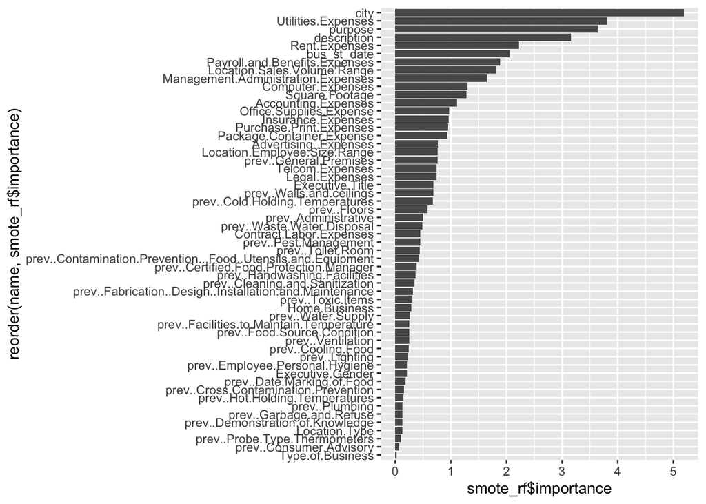

```r
# Model
smote_rf = randomForest(formula = outcome ~ ., data=smoted_df_final, ntrees=15)

# Variable Importance Plot
ggplot(data=smote_rf$importance %>% as.data.frame() %>%
         mutate(name=as.factor(rownames(.))) %>%
         mutate(name=factor(name, name))) +
  geom_bar(aes(x=reorder(name, smote_rf$importance), y=smote_rf$importance), stat="identity") + coord_flip()
```

```r
# RF predictions
smote_rf_pred <- predict(smote_rf, binary_test_feat, n.trees=15, type = "prob")[, 2]

# ROCR object
smote_rf_rocr = prediction(smote_rf_pred, binary_test_outcome)

# Get AUC
smote_rf_auc = performance(smote_rf_rocr, measure = "auc")
smote_rf_auc@y.values
```

```
## [[1]]
## [1] 0.5800138
```

```r
# Get ROC
smote_rf_roc = performance(smote_rf_rocr, measure = "tpr", x.measure = "fpr")
```

Interestingly, on the SMOTE dataset, the random forest has different top important variables like Utilities Expense and Rent Expense.

We will graph the two ROC curves in order to compare the outcomes of the models.

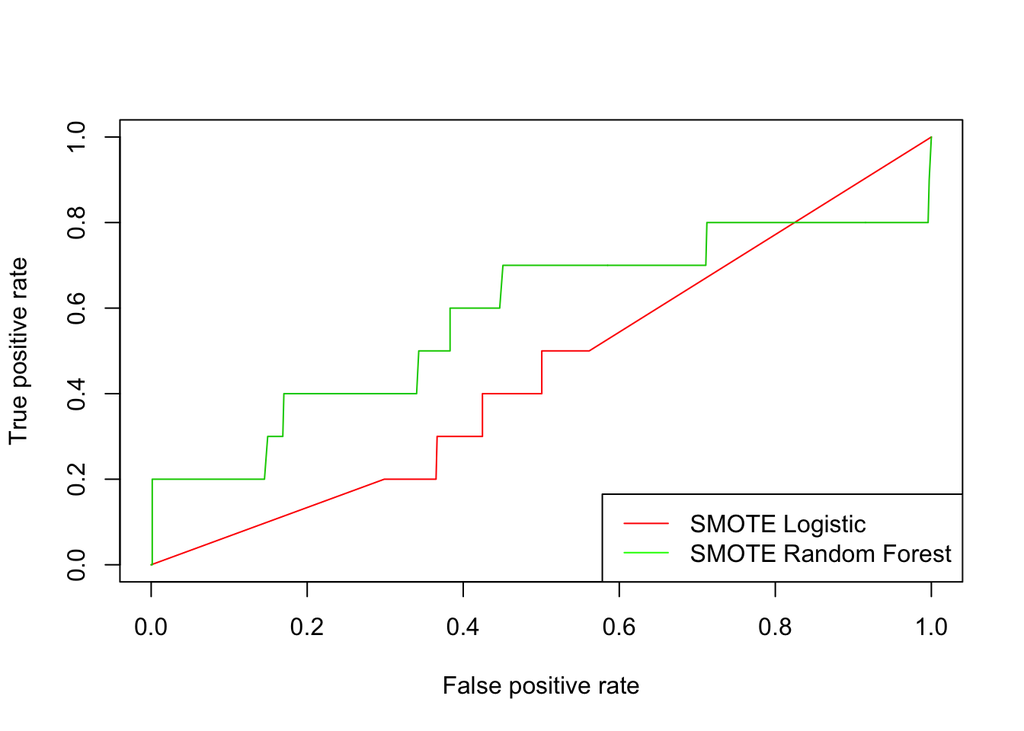

```r
plot(smote_logit_roc , col = 2)
plot(smote_rf_roc, col = 3, add = TRUE)
legend("bottomright", c("SMOTE Logistic", "SMOTE Random Forest"), lty=1, col = c("red", "green"))
```

Let’s look into comparisons of sensitivity. Because SMOTE oversamples positive values, it should do a better job of detecting positives.

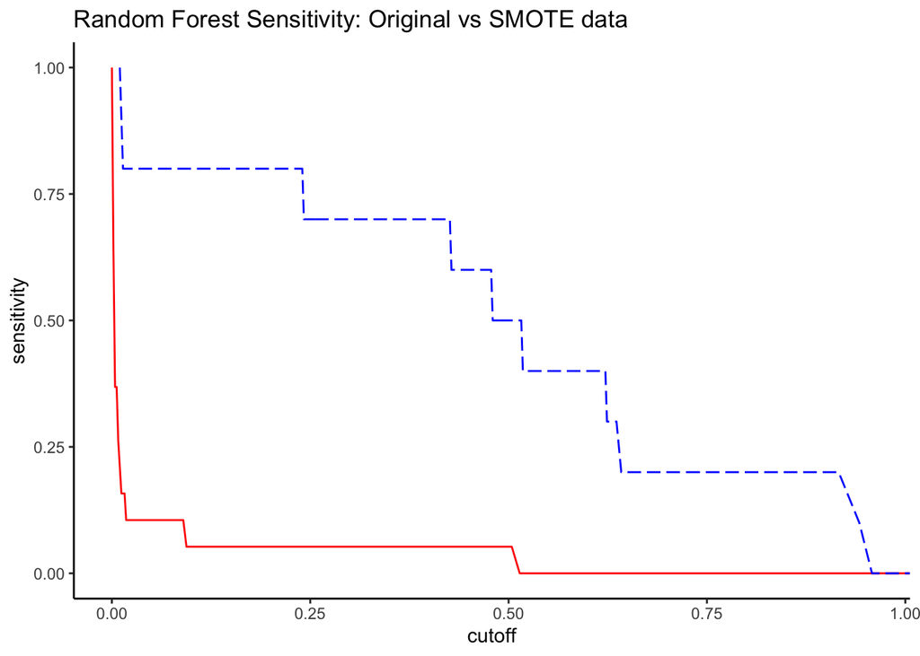

```r
rf_sens = performance(bin_rf_rocr, measure = "sens")
smote_rf_sens = performance(smote_rf_rocr, measure = "sens")

library(ggplot2)
rf_x = rf_sens@x.values[[1]]
rf_y = rf_sens@y.values[[1]]
rf_df = data.frame(cutoff = rf_x, sensitivity = rf_y)

smote_rf_x = smote_rf_sens@x.values[[1]]
smote_rf_y = smote_rf_sens@y.values[[1]]
smote_rf_df = data.frame(cutoff = smote_rf_x, sensitivity = smote_rf_y)

ggplot() +
  geom_line(data = rf_df, mapping = aes(x = cutoff, y = sensitivity), color = "red")+
  geom_line(data = smote_rf_df, mapping = aes(x = cutoff, y = sensitivity), color = "blue", linetype="longdash") +
  labs(title = "Random Forest Sensitivity: Original vs SMOTE data") +
  theme_classic()
```